# SST Paper generation

### median, all trials

```r
model_P_stop_trial_w_change <- lme4::lmer(
   med_post_trial_z ~ trial_n_z + post_pre_rt_change_z + P_stop_trial_change_z +(1+ post_pre_rt_change_z + P_stop_trial_change_z  | subid),
  trial_neural_behav_roi %>% filter(condition %in% c("FailedStop"))
  )
```

```
## boundary (singular) fit: see help('isSingular')
```

```r
summary(model_P_stop_trial_w_change)
```

```
## Linear mixed model fit by REML ['lmerMod']
## Formula:
## med_post_trial_z ~ trial_n_z + post_pre_rt_change_z + P_stop_trial_change_z +
##     (1 + post_pre_rt_change_z + P_stop_trial_change_z | subid)
##    Data: trial_neural_behav_roi %>% filter(condition %in% c("FailedStop"))
##
## REML criterion at convergence: 10684.5
##
## Scaled residuals:
##     Min      1Q  Median      3Q     Max
## -6.7521 -0.5992  0.0089  0.6137  4.0204
##
## Random effects:
##  Groups   Name                  Variance  Std.Dev. Corr
##  subid    (Intercept)           0.0479603 0.21900
##           post_pre_rt_change_z  0.0004153 0.02038  -1.00
##           P_stop_trial_change_z 0.0018478 0.04299  -0.21  0.21
##  Residual                       0.9722778 0.98604
## Number of obs: 3745, groups:  subid, 228
##
## Fixed effects:
##                       Estimate Std. Error t value
## (Intercept)           -0.21584    0.02584  -8.353
## trial_n_z             -0.01706    0.01869  -0.913
## post_pre_rt_change_z  -0.01365    0.01604  -0.851
## P_stop_trial_change_z -0.09094    0.01210  -7.514
##
## Correlation of Fixed Effects:
##             (Intr) trl_n_ ps____
## trial_n_z   -0.096
## pst_pr_rt__ -0.381  0.006
## P_stp_trl__ -0.436  0.519  0.169
## optimizer (nloptwrap) convergence code: 0 (OK)
## boundary (singular) fit: see help('isSingular')
```

```r
#ignoring post_pre_rt_change_z
model_P_stop_trial_w_change_no_rt <- lme4::lmer(
   med_post_trial_z ~ trial_n_z  + P_stop_trial_change_z +(1+ post_pre_rt_change_z + P_stop_trial_change_z  | subid),
  trial_neural_behav_roi %>% filter(condition %in% c("FailedStop"))
  )
summary(model_P_stop_trial_w_change_no_rt)
```

```
## Linear mixed model fit by REML ['lmerMod']
## Formula:
## med_post_trial_z ~ trial_n_z + P_stop_trial_change_z + (1 + post_pre_rt_change_z +
##     P_stop_trial_change_z | subid)
##    Data: trial_neural_behav_roi %>% filter(condition %in% c("FailedStop"))
##
## REML criterion at convergence: 10678.7
##
## Scaled residuals:
##     Min      1Q  Median      3Q     Max
## -6.7461 -0.6046  0.0105  0.6094  4.0296
##
## Random effects:
##  Groups   Name                  Variance Std.Dev. Corr
##  subid    (Intercept)           0.047557 0.21808
##           post_pre_rt_change_z  0.001251 0.03537  -0.56
##           P_stop_trial_change_z 0.001643 0.04054  -0.19 -0.27
##  Residual                       0.971616 0.98571
## Number of obs: 3745, groups:  subid, 228
##
## Fixed effects:
##                       Estimate Std. Error t value
## (Intercept)           -0.22388    0.02389  -9.372
## trial_n_z             -0.01695    0.01869  -0.907
## P_stop_trial_change_z -0.08937    0.01189  -7.515
##
## Correlation of Fixed Effects:
##             (Intr) trl_n_
## trial_n_z   -0.101
## P_stp_trl__ -0.410  0.526
```

```r
anova(model_P_stop_trial_w_change,model_P_stop_trial_w_change_no_rt)
```

```
## refitting model(s) with ML (instead of REML)
```

```
## Data: trial_neural_behav_roi %>% filter(condition %in% c("FailedStop"))
## Models:
## model_P_stop_trial_w_change_no_rt: med_post_trial_z ~ trial_n_z + P_stop_trial_change_z + (1 + post_pre_rt_change_z + P_stop_trial_change_z | subid)
## model_P_stop_trial_w_change: med_post_trial_z ~ trial_n_z + post_pre_rt_change_z + P_stop_trial_change_z + (1 + post_pre_rt_change_z + P_stop_trial_change_z | subid)
##                                   npar   AIC   BIC  logLik deviance  Chisq Df
## model_P_stop_trial_w_change_no_rt   10 10679 10742 -5329.7    10659
## model_P_stop_trial_w_change         11 10681 10749 -5329.4    10659 0.6046  1
##                                   Pr(>Chisq)
## model_P_stop_trial_w_change_no_rt
## model_P_stop_trial_w_change           0.4368
```

```r
#ignoring P_stop_trial_change_z
model_P_stop_trial_w_change_no_p_stop_d <- lme4::lmer(
   med_post_trial_z ~ trial_n_z +  post_pre_rt_change_z +(1+ post_pre_rt_change_z + P_stop_trial_change_z | subid),
  trial_neural_behav_roi %>% filter(condition %in% c("FailedStop"))
  )
summary(model_P_stop_trial_w_change_no_p_stop_d)
```

```
## Linear mixed model fit by REML ['lmerMod']
## Formula:
## med_post_trial_z ~ trial_n_z + post_pre_rt_change_z + (1 + post_pre_rt_change_z +
##     P_stop_trial_change_z | subid)
##    Data: trial_neural_behav_roi %>% filter(condition %in% c("FailedStop"))
##
## REML criterion at convergence: 10727
##
## Scaled residuals:
##     Min      1Q  Median      3Q     Max
## -6.7761 -0.5980  0.0188  0.6181  3.9583
##
## Random effects:
##  Groups   Name                  Variance  Std.Dev. Corr
##  subid    (Intercept)           0.0530028 0.23022
##           post_pre_rt_change_z  0.0006864 0.02620  -0.83
##           P_stop_trial_change_z 0.0075927 0.08714  -0.38  0.53
##  Residual                       0.9733528 0.98659
## Number of obs: 3745, groups:  subid, 228
##
## Fixed effects:
##                       Estimate Std. Error t value
## (Intercept)          -0.296669   0.023321 -12.721
## trial_n_z             0.042015   0.016477   2.550
## post_pre_rt_change_z  0.002371   0.015963   0.149
##
## Correlation of Fixed Effects:
##             (Intr) trl_n_
## trial_n_z    0.162
## pst_pr_rt__ -0.346 -0.087
## optimizer (nloptwrap) convergence code: 0 (OK)
## Model failed to converge with max|grad| = 0.0160841 (tol = 0.002, component 1)
```

```r
anova(model_P_stop_trial_w_change, model_P_stop_trial_w_change_no_p_stop_d)
```

```
## refitting model(s) with ML (instead of REML)
```

```
## Data: trial_neural_behav_roi %>% filter(condition %in% c("FailedStop"))
## Models:
## model_P_stop_trial_w_change_no_p_stop_d: med_post_trial_z ~ trial_n_z + post_pre_rt_change_z + (1 + post_pre_rt_change_z + P_stop_trial_change_z | subid)
## model_P_stop_trial_w_change: med_post_trial_z ~ trial_n_z + post_pre_rt_change_z + P_stop_trial_change_z + (1 + post_pre_rt_change_z + P_stop_trial_change_z | subid)
##                                         npar   AIC   BIC  logLik deviance
## model_P_stop_trial_w_change_no_p_stop_d   10 10728 10791 -5354.2    10708
## model_P_stop_trial_w_change               11 10681 10749 -5329.4    10659
##                                          Chisq Df Pr(>Chisq)
## model_P_stop_trial_w_change_no_p_stop_d
## model_P_stop_trial_w_change             49.654  1  1.834e-12 ***
## ---
## Signif. codes:  0 '***' 0.001 '**' 0.01 '*' 0.05 '.' 0.1 ' ' 1
```

#### distribution thereof

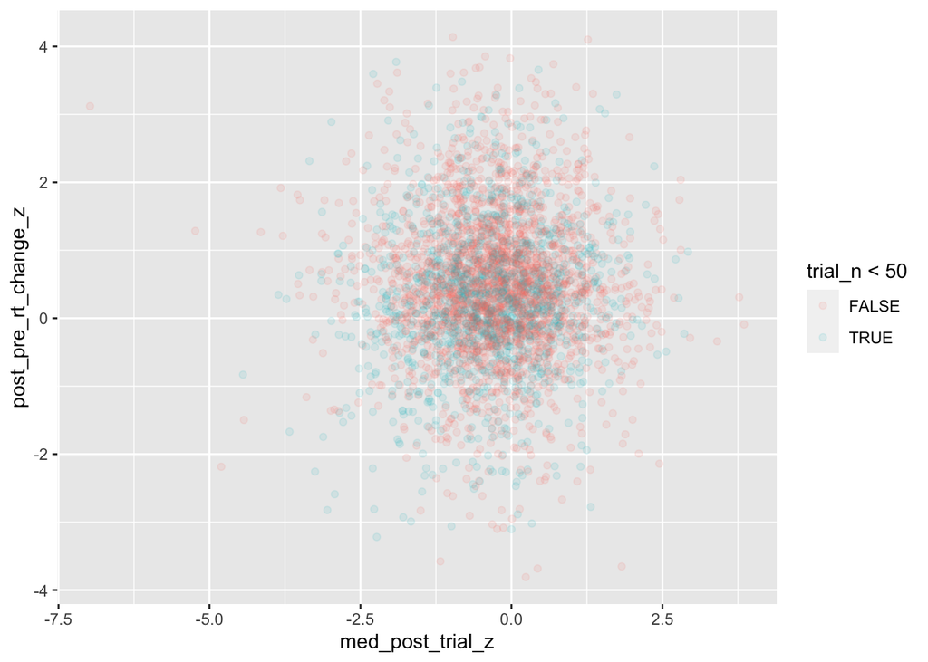

```r
# plot a ggplot2 point graph of trial_neural_behav_roi filtered by FailedStop, plotting med_post_trial_z against post_pre_rt_change_z
# coloring points by whether trial_n is <50 or not

ggplot(data = trial_neural_behav_roi %>%
          filter(condition=="FailedStop"),
        aes(x = med_post_trial_z,
            y = post_pre_rt_change_z,
            color = trial_n < 50)) +
   geom_point(alpha=0.1)
```

# Table 3: Post-Fail Spike

This is modeled in more detail in `modeling_t_1_5_activity_as_learning.Rmd`. ## Just FS Trials

```r
count_subs <- function(ds){length(unique(ds$subid))}

count_subs(trial_summary_data)
```

```
## [1] 235
```

```r
count_subs(trial_summary_data_delat)
```

```
## [1] 235
```

```r
count_subs(trial_summary_data_delat_pp)
```

```
## [1] 235
```

```r
count_subs(trial_neural_behav_data_not_na)
```

```
## [1] 228
```

```r
subjects_in_table_3_analysis <- unique(trial_neural_behav_roi$subid)
length(subjects_in_table_3_analysis)
```

```
## [1] 228
```

```r
print(subjects_in_table_3_analysis)
```

```
##   [1] "DEV006" "DEV008" "DEV013" "DEV014" "DEV015" "DEV016" "DEV018" "DEV019"
##   [9] "DEV020" "DEV021" "DEV022" "DEV023" "DEV024" "DEV026" "DEV027" "DEV028"
##  [17] "DEV029" "DEV030" "DEV031" "DEV033" "DEV034" "DEV035" "DEV036" "DEV037"
##  [25] "DEV038" "DEV040" "DEV041" "DEV042" "DEV043" "DEV044" "DEV045" "DEV046"
##  [33] "DEV047" "DEV048" "DEV049" "DEV051" "DEV052" "DEV053" "DEV054" "DEV056"
##  [41] "DEV057" "DEV058" "DEV059" "DEV060" "DEV062" "DEV063" "DEV065" "DEV068"
##  [49] "DEV070" "DEV071" "DEV072" "DEV073" "DEV074" "DEV075" "DEV076" "DEV077"
##  [57] "DEV078" "DEV079" "DEV080" "DEV081" "DEV082" "DEV083" "DEV084" "DEV085"
##  [65] "DEV086" "DEV087" "DEV088" "DEV089" "DEV090" "DEV093" "DEV094" "DEV095"
##  [73] "DEV096" "DEV097" "DEV099" "DEV100" "DEV102" "DEV103" "DEV104" "DEV105"
##  [81] "DEV106" "DEV107" "DEV108" "DEV109" "DEV110" "DEV111" "DEV112" "DEV113"
##  [89] "DEV114" "DEV115" "DEV116" "DEV118" "DEV119" "DEV120" "DEV121" "DEV122"
##  [97] "DEV123" "DEV124" "DEV127" "DEV128" "DEV129" "DEV130" "DEV131" "DEV132"
## [105] "DEV133" "DEV134" "DEV135" "DEV137" "DEV139" "DEV140" "DEV141" "DEV144"
## [113] "DEV145" "DEV147" "DEV149" "DEV150" "DEV151" "DEV152" "DEV153" "DEV154"
## [121] "DEV155" "DEV156" "DEV157" "DEV158" "DEV159" "DEV161" "DEV164" "DEV166"
## [129] "DEV167" "DEV168" "DEV169" "DEV170" "DEV171" "DEV172" "DEV173" "DEV174"
## [137] "DEV177" "DEV178" "DEV179" "DEV180" "DEV182" "DEV183" "DEV187" "DEV188"
## [145] "DEV191" "DEV192" "DEV193" "DEV194" "DEV195" "DEV197" "DEV199" "DEV200"
## [153] "DEV201" "DEV202" "DEV205" "DEV206" "DEV208" "DEV209" "DEV210" "DEV211"
## [161] "DEV215" "DEV216" "DEV217" "DEV220" "DEV222" "DEV223" "DEV224" "DEV225"
## [169] "DEV228" "DEV230" "DEV232" "DEV233" "DEV235" "DEV236" "DEV237" "DEV238"
## [177] "DEV239" "DEV240" "DEV241" "DEV244" "DEV246" "DEV249" "DEV251" "DEV252"
## [185] "DEV253" "DEV254" "DEV256" "DEV257" "DEV258" "DEV259" "DEV260" "DEV261"
## [193] "DEV262" "DEV263" "DEV264" "DEV266" "DEV267" "DEV268" "DEV269" "DEV270"
## [201] "DEV271" "DEV272" "DEV275" "DEV276" "DEV277" "DEV282" "DEV284" "DEV285"
## [209] "DEV290" "DEV291" "DEV292" "DEV293" "DEV294" "DEV296" "DEV297" "DEV298"
## [217] "DEV300" "DEV302" "DEV303" "DEV304" "DEV305" "DEV306" "DEV307" "DEV308"
## [225] "DEV309" "DEV310" "DEV311" "DEV312"
```

```r
model_P_stop_trial_w_change <- lme4::lmer(
   med_post_trial_1_5 ~ trial_n_z + post_pre_rt_change_z + P_stop_trial_change_z +(1+ post_pre_rt_change_z + P_stop_trial_change_z  | subid),
  trial_neural_behav_roi %>% filter(trial_n>50 & condition %in% c("FailedStop"))
  )
```

```
## boundary (singular) fit: see help('isSingular')
```

```r
summary(model_P_stop_trial_w_change)
```

```
## Linear mixed model fit by REML ['lmerMod']
## Formula:
## med_post_trial_1_5 ~ trial_n_z + post_pre_rt_change_z + P_stop_trial_change_z +
##     (1 + post_pre_rt_change_z + P_stop_trial_change_z | subid)
##    Data: trial_neural_behav_roi %>% filter(trial_n > 50 & condition %in%
##     c("FailedStop"))
##
## REML criterion at convergence: 3277.8
##
## Scaled residuals:
##     Min      1Q  Median      3Q     Max
## -7.7679 -0.5363  0.0475  0.5972  3.0947
##
## Random effects:
##  Groups   Name                  Variance Std.Dev. Corr
##  subid    (Intercept)           0.000000 0.00000
##           post_pre_rt_change_z  0.004889 0.06992    NaN
##           P_stop_trial_change_z 0.056987 0.23872    NaN -0.23
##  Residual                       0.210527 0.45883
## Number of obs: 2458, groups:  subid, 227
##
## Fixed effects:
##                        Estimate Std. Error t value
## (Intercept)           -0.098189   0.060507  -1.623
## trial_n_z              0.041173   0.028728   1.433
## post_pre_rt_change_z   0.007256   0.010475   0.693
## P_stop_trial_change_z  0.469540   0.166751   2.816
##
## Correlation of Fixed Effects:
##             (Intr) trl_n_ ps____
## trial_n_z   -0.925
## pst_pr_rt__ -0.073  0.001
## P_stp_trl__ -0.977  0.905 -0.001
## optimizer (nloptwrap) convergence code: 0 (OK)
## boundary (singular) fit: see help('isSingular')
```

```r
#ignoring post_pre_rt_change_z
model_P_stop_trial_w_change_no_rt <- lme4::lmer(
   med_post_trial_1_5 ~ trial_n_z  + P_stop_trial_change_z +(1+ post_pre_rt_change_z + P_stop_trial_change_z  | subid),
  trial_neural_behav_roi %>% filter(trial_n>50 & condition %in% c("FailedStop"))
  )
```

```
## boundary (singular) fit: see help('isSingular')
```

```r
#summary(model_P_stop_trial_w_change_no_rt)

anova(model_P_stop_trial_w_change,model_P_stop_trial_w_change_no_rt)
```

```
## refitting model(s) with ML (instead of REML)
```

```
## Data: trial_neural_behav_roi %>% filter(trial_n > 50 & condition %in%  ...
## Models:
## model_P_stop_trial_w_change_no_rt: med_post_trial_1_5 ~ trial_n_z + P_stop_trial_change_z + (1 + post_pre_rt_change_z + P_stop_trial_change_z | subid)
## model_P_stop_trial_w_change: med_post_trial_1_5 ~ trial_n_z + post_pre_rt_change_z + P_stop_trial_change_z + (1 + post_pre_rt_change_z + P_stop_trial_change_z | subid)
##                                   npar    AIC    BIC  logLik deviance Chisq Df
## model_P_stop_trial_w_change_no_rt   10 3275.0 3333.1 -1627.5   3255.0
## model_P_stop_trial_w_change         11 3276.6 3340.4 -1627.3   3254.6 0.484  1
##                                   Pr(>Chisq)
## model_P_stop_trial_w_change_no_rt
## model_P_stop_trial_w_change           0.4866
```

```r
#ignoring P_stop_trial_change_z
model_P_stop_trial_w_change_no_p_stop_d <- lme4::lmer(
   med_post_trial_1_5 ~ trial_n_z +  post_pre_rt_change_z +(1+ post_pre_rt_change_z + P_stop_trial_change_z | subid),
  trial_neural_behav_roi %>% filter(trial_n>50 & condition %in% c("FailedStop"))
  )
```

```
## boundary (singular) fit: see help('isSingular')
```

```r
#summary(model_P_stop_trial_w_change_no_p_stop_d)


anova(model_P_stop_trial_w_change, model_P_stop_trial_w_change_no_p_stop_d)
```

```
## refitting model(s) with ML (instead of REML)
```

```
## Data: trial_neural_behav_roi %>% filter(trial_n > 50 & condition %in%  ...
## Models:
## model_P_stop_trial_w_change_no_p_stop_d: med_post_trial_1_5 ~ trial_n_z + post_pre_rt_change_z + (1 + post_pre_rt_change_z + P_stop_trial_change_z | subid)
## model_P_stop_trial_w_change: med_post_trial_1_5 ~ trial_n_z + post_pre_rt_change_z + P_stop_trial_change_z + (1 + post_pre_rt_change_z + P_stop_trial_change_z | subid)
##                                         npar    AIC    BIC  logLik deviance
## model_P_stop_trial_w_change_no_p_stop_d   10 3282.5 3340.5 -1631.2   3262.5
## model_P_stop_trial_w_change               11 3276.6 3340.4 -1627.3   3254.6
##                                          Chisq Df Pr(>Chisq)
## model_P_stop_trial_w_change_no_p_stop_d
## model_P_stop_trial_w_change             7.8911  1   0.004968 **
## ---
## Signif. codes:  0 '***' 0.001 '**' 0.01 '*' 0.05 '.' 0.1 ' ' 1
```

```r
model_list <- list("RT Only"=model_P_stop_trial_w_change_no_p_stop_d,
                   "P(Stop) Only"=model_P_stop_trial_w_change_no_rt,
                   "Full model"=model_P_stop_trial_w_change
                   )


friendly_name_transform_table<-read_csv("friendly_names.csv")
table_cells <- create_sst_mlm_table(
  model_list,name_transform =friendly_name_transform_table,
  "Median Activity 1-5 s Post-Stop Signal")
```

```
## refitting model(s) with ML (instead of REML)
## refitting model(s) with ML (instead of REML)
## refitting model(s) with ML (instead of REML)
```

[output not shown]

```r
gtsave(table_cells,filename = "table3.html")
```

```r
table_normed <- stargazer(model_P_stop_trial_w_change, model_P_stop_trial_w_change_no_rt, model_P_stop_trial_w_change_no_p_stop_d,title="Post-Fail Spike")
```

```r
#
```

# get the delay to next trial

```r
behavioral_data_w_tone_data <- readr::read_csv(paste0(dropbbox_dir,"/sst_behavioral_data_all_w_class_type_reveal_onset.csv"))
```

[output not shown]

```r
# I want to know: what is the time delay from the tone sound to the PERIOD of the next trial?
```

```r
#so I want to match each trial up with the _next_ trial
#grab the set of next trials-we want their onset and their duration
#then match that back onto n+1 of their prior trial
trial_df <- behavioral_data_w_tone_data %>% filter(condition!="Cue") %>%
  arrange(trial_n) %>%
  group_by(subid,waveid,runid) %>%
  mutate(next_trial_n = lead(trial_n,1)) %>%
  ungroup()


next_trial_df <- behavioral_data_w_tone_data %>%
  filter(condition!="Cue") %>%
  select(trial_n,condition,onset,trial_duration,subid,waveid,runid)


trials_with_next<-merge(
  trial_df,next_trial_df,
  by.x = c("subid","waveid","runid", "next_trial_n"),
  by.y=c("subid","waveid","runid","trial_n"),
  suffixes = c("","_next"))
```

now, mark for each trial the start and end time point of the next trial, and get measures of how long after each trial the next one appears

```r
trials_with_next$trial_end_next <- trials_with_next$onset_next+trials_with_next$trial_duration_next
trials_with_next$class_type_reveal_onset_to_next_trial_start<-trials_with_next$onset_next-trials_with_next$class_type_reveal_onset
trials_with_next$class_type_reveal_onset_to_next_trial_end<-trials_with_next$trial_end_next-trials_with_next$class_type_reveal_onset
```

```r
next_trial_median <- data.frame(
  "next_trial_start_median" = median(trials_with_next$class_type_reveal_onset_to_next_trial_start),
  "next_trial_end_median" = median(trials_with_next$class_type_reveal_onset_to_next_trial_end)
  )

quantiles <- (1:10)/10
# next_trial_gradient <- data.frame(
#   "quantiles" = quantiles,
#   "next_trial_start" = quantile(trials_with_next$class_type_reveal_onset_to_next_trial_start,(1:10)/10),
#   "next_trial_end" = quantile(trials_with_next$class_type_reveal_onset_to_next_trial_end,(1:10)/10)
#   )

gradient_range = seq(floor(min(trials_with_next$class_type_reveal_onset_to_next_trial_start)),ceiling(max(trials_with_next$class_type_reveal_onset_to_next_trial_end)),0.1)

in_range_by_gradient <- sapply(gradient_range,function(tp){
  time_point_is_after_start <- tp > trials_with_next$class_type_reveal_onset_to_next_trial_start
  time_point_is_before_end <- tp < trials_with_next$class_type_reveal_onset_to_next_trial_end
  number_of_trials <- length(trials_with_next$class_type_reveal_onset_to_next_trial_start)
  return(sum(time_point_is_after_start & time_point_is_before_end)/number_of_trials)
})

next_trial_gradient <- data.frame("tp"=gradient_range,"pct_in_range"=in_range_by_gradient)
next_trial_gradient$hrf_tp<-next_trial_gradient$tp+5
```

# do graphs

```r
subj_count <- length(unique(time_points_c$subid))
#df_offset_long<-df_offset# %>% pivot_longer(cols=roi_cols,names_to="ROI_fullname",values_to="value")
# df_offset_long$ROI<-stringr::str_extract_all(df_offset_long$ROI_fullname,pattern = "(?<=harvardoxford\\..{0,3}cortical_prob_)(.*)") %>% sub("\\."," ",.)

# unique_rois<-sort(unique(df_offset_long$ROI))
# unique_rois_ordered <- unique_rois[order(unique_rois %>% str_extract("(?<=.{3,5}\\s)(.*)"))]

# df_offset_long$ROI<-factor(df_offset_long$ROI,levels = unique_rois_ordered, ordered=TRUE)

ggplot_time_points_extras <- list(
  geom_vline(xintercept = 0,linetype="dashed"),
  geom_hline(yintercept = 0,linetype="dotted"),
  labs(
    x="time from tone sound or expected time of tone (s)",
    y="mean BOLD activity (no HRF convolution)",
    #title="Stop Signal Task Activity",
    subtitle=paste0("Across ", as.character(subj_count)," subjects with 128 trials each"),
    caption="0 point is the moment of tone sound (Stop trials)\n or expected tone sound based on prior trial (Go trials)\n HRF convolution not applied\n1 s moving averages")
  )


plot_final<-ggplot(df_offset,
       aes(x=offset_start, y=`CueFollowing(CS>FS)striatal_cluster_combined`,color=condition))+
  geom_line()+
  #facet_wrap(~ROI,ncol = 2)+
  ggplot_time_points_extras

  #geom_point()+
  #geom_smooth(method="loess",span=2,na.rm=TRUE) + #https://ggplot2.tidyverse.org/reference/geom_smooth.html
  #scale_y_continuous(limits=c(-2.5,2.5))
```

## CS-FS

Let’s now try to contrast these time series to see what the CS-FS looks like. This will be interesting because it’s similar to the simple GLM result I got earlier that set me down the path of trying to analyze this.

```r
trial_tps_compare_conditions<-df_offset %>% pivot_wider(
  id_cols=c(offset_start),
  names_from = "condition",
  values_from="CueFollowing(CS>FS)striatal_cluster_combined"
  )
trial_tps_compare_conditions$CS_minus_FS<-trial_tps_compare_conditions$CorrectStop-trial_tps_compare_conditions$FailedStop
```

### Figure 2:

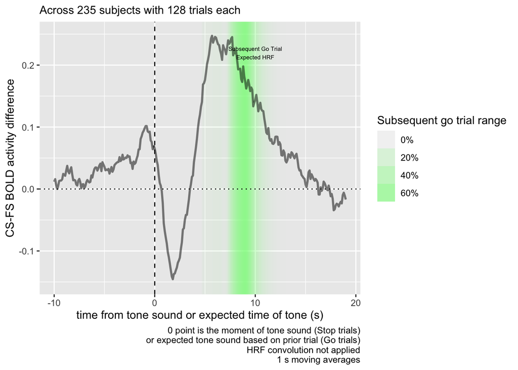

```r
ggplot(trial_tps_compare_conditions,
       aes(x=offset_start, y=CS_minus_FS))+
  #geom_tile(data = next_trial_gradient, aes(x=tp,alpha=pct_in_range,y=0),fill="#000000",color="transparent")+
  geom_tile(data = next_trial_gradient, aes(x=hrf_tp,alpha=pct_in_range,y=0),fill="#77ff77",color="transparent")+
  #annotate("text",x=4,y=0.25,label="Subsequent Go Trial\nTime Range",size=2)+
  annotate("text",x=10,y=0.22,label="Subsequent Go Trial\nExpected HRF",size=2)+
  scale_alpha_continuous(name="Subsequent go trial range", range=c(0,0.7),labels=scales::percent_format())+
  geom_line(size=1,alpha=0.5)+
  scale_color_viridis_d(option = "C")+
  ggplot_time_points_extras+
  coord_cartesian(ylim=c(-0.15,0.25))+
  labs(y="CS-FS BOLD activity difference")
```

OK, so from this graph it is very clear why, during the subsequent trial, we’re seeing positive striatum activity, and it is also clear there is a large dip in the same area right after the tone.

## Figure 3:

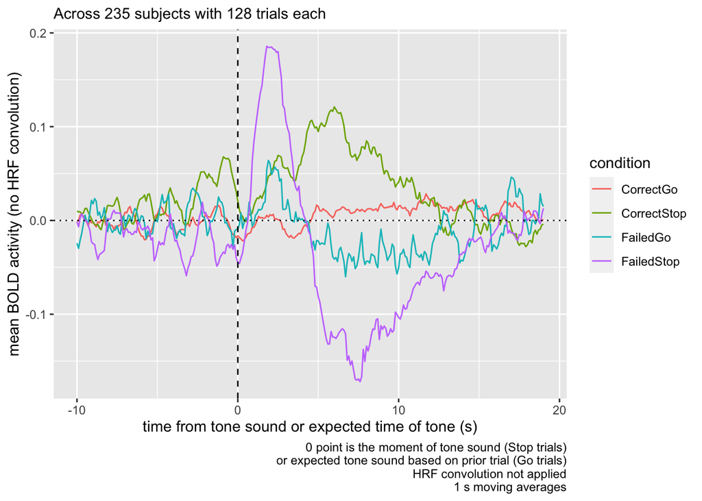

```r
count_subjs <- function(df){length(unique(df$subid))}
subj_count <- length(unique(time_points_c$subid))
ggplot(df_offset,
       aes(x=offset_start, y=`CueFollowing(CS>FS)striatal_cluster_combined`,color=condition))+
  geom_line()+
  #facet_wrap(~ROI,ncol = 2)+
  ggplot_time_points_extras
```

# Figure 4 and 5

## Just stop trials, divided separately

```r
get_roi_good_names <- function(roi_fullname_col){

  roi_organized<-stringr::str_extract_all(unlist(roi_fullname_col),pattern = "(?<=harvardoxford\\.(sub)?cortical_prob_)(.*)") %>% sub("\\.\\.",", ",.) %>% gsub("\\."," ",.)
  #print(roi_organized)
  unique_rois<-sort(unique(roi_organized))
  unique_rois_ordered <- unique_rois[order(unique_rois %>% str_extract("(?<=.{3,5}\\s)(.*)"))]
  print(unique_rois)
  roi_factor_col<-factor(roi_organized,levels = unique_rois_ordered, ordered=TRUE)
  return(roi_factor_col)
}
```

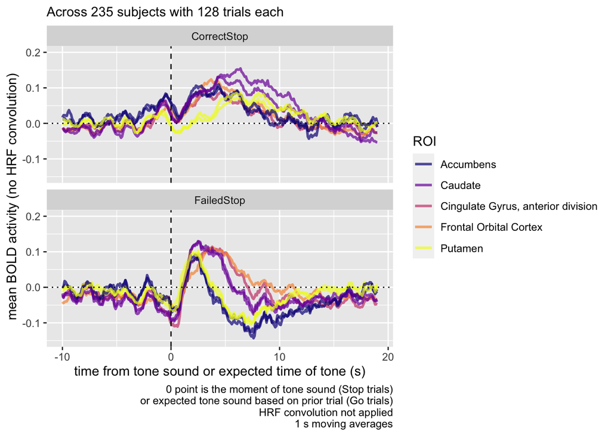

```r
#roi_cols <- colnames(df_offset)[grepl("harvardoxford",colnames(df_offset))]
df_offset_long<-df_offset %>% pivot_longer(cols=anatomical_roi_cols,names_to="ROI",values_to="value")

#df_offset_long$ROI<-get_roi_good_names(df_offset_long$ROI)
df_offset_long$ROI_bilat <- sub("(Left )|(Right )","",df_offset_long$ROI)

next_trial_gradient$hrf_tp<-next_trial_gradient$tp+5

ggplot(df_offset_long %>% filter(condition %in% c("FailedStop","CorrectStop")),
       aes(x=offset_start, y=value,color=ROI_bilat,group=ROI))+
  facet_wrap(~condition,nrow = 2)+
  #geom_tile(data = next_trial_gradient, aes(x=hrf_tp,alpha=pct_in_range,y=0),fill="#77ff77",color="transparent")+
  #annotate("text",x=10,y=0.22,label="Subsequent Go Trial\nExpected HRF",size=2)+
  geom_line(size=1,alpha=0.7)+

  scale_color_viridis_d(option = "C")+
  coord_cartesian(ylim=c(-0.15,0.2))+
  guides(alpha="none",color=guide_legend(title="ROI"))+
  #guides(alpha="none",color=guide_legend(title="ROI",nrow = 2))+
  ggplot_time_points_extras#+
```

```r
  #theme(legend.position = "bottom")


#ggplot(df_offset_long,aes(x=offset_start, y=value,color=ROI,group=intersect(ROI,condition)))+geom_line()
  #geom_point()+
  #geom_smooth(method="loess",span=2,na.rm=TRUE) + #https://ggplot2.tidyverse.org/reference/geom_smooth.html
  #scale_y_continuous(limits=c(-2.5,2.5))
```

```r
trial_tps_compare_conditions<-df_offset_long %>% pivot_wider(id_cols=c(ROI, ROI_bilat,offset_start),names_from = "condition",values_from="value")
trial_tps_compare_conditions$CS_minus_FS<-trial_tps_compare_conditions$CorrectStop-trial_tps_compare_conditions$FailedStop
```

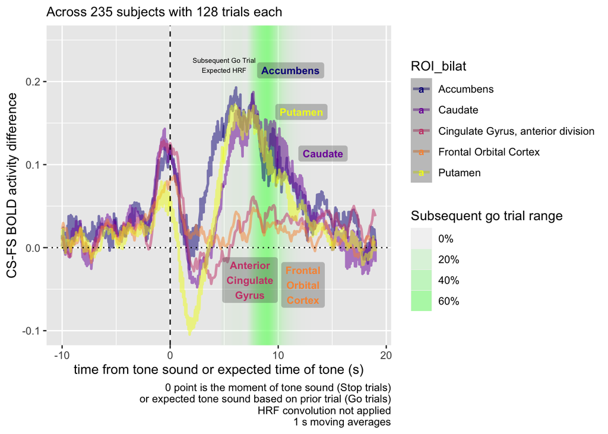

```r
library(directlabels)
library(ggrepel)

labels <- trial_tps_compare_conditions %>% filter(offset_start==9) %>% group_by(ROI_bilat) %>%
  slice(1)
#labels <- labels %>% mutate(y_pos=CS_minus_FS+(CS_minus_FS-mean(CS_minus_FS))*3)
labels$ROI_labels <- gsub(" ","\n",labels$ROI_bilat)
labels$ROI_labels <- gsub("Cingulate\nGyrus,\nanterior\ndivision", "Anterior\nCingulate\nGyrus",labels$ROI_labels)


labels <- labels %>% arrange(ROI_labels)
labels$xpos <- c(10,6,13,10,11)
labels$ypos <- c(0.2,-0.07,0.1,-0.07,0.15)

ggplot(trial_tps_compare_conditions, aes(x=offset_start, y=CS_minus_FS,color=ROI_bilat))+
  geom_tile(data = next_trial_gradient, aes(x=hrf_tp,alpha=pct_in_range,y=0),fill="#77ff77",color="transparent")+

  annotate("text",x=5,y=0.22,label="Subsequent Go Trial\nExpected HRF",size=2)+
  scale_alpha_continuous(name="Subsequent go trial range", range=c(0,0.7),labels=scales::percent_format())+
  geom_line(size=1,alpha=0.5)+
  #geom_text(data=labels,mapping= aes(x=offset_start,y=CS_minus_FS,color=ROI_bilat,label=ROI_bilat))+
  # geom_text_repel(data = labels,  aes(x=offset_start,y=CS_minus_FS,label=ROI_labels),color="#333333",
  #                 size = 3, fontface = "bold",force=2,box.padding=0.1, point.padding = 10, nudge_x = -3*1.01,nudge_y = 0.01*1.1)+
  geom_label_repel(data = labels,
                   #aes(x=offset_start,y=y_pos,color=ROI_bilat,label=ROI_labels),
                   aes(x=xpos,y=ypos,color=ROI_bilat,label=ROI_labels),
                   size = 3, fontface = "bold",force=2,box.padding=0.1, label.size =0,
                   nudge_x = 1,nudge_y = 0.01,fill=rgb(0.3,0.3,0.3,alpha=0.3)
                   )+
  scale_color_viridis_d(option = "C")+
  ggplot_time_points_extras+
  coord_cartesian(ylim=c(-0.1,0.25))+
  labs(y="CS-FS BOLD activity difference")
```